# Part 1: Setting up the Project

```python
UCDP.corr() # after NaNs replaced by column median...0.770295
```

|  | index | Year | Kilometers_Driven | Mileage | Engine | Power | Seats | New_Price | Price |
| --- | --- | --- | --- | --- | --- | --- | --- | --- | --- |
| index | 1.000000 | 0.005592 | -0.002536 | 0.013662 | -0.013725 | -0.020791 | -0.006673 | -0.064992 | -0.020374 |
| Year | 0.005592 | 1.000000 | -0.449596 | 0.295442 | -0.052406 | 0.024941 | 0.008220 | -0.058784 | 0.305355 |
| Kilometers_Driven | -0.002536 | -0.449596 | 1.000000 | -0.142581 | 0.157625 | -0.002005 | 0.211914 | -0.008109 | -0.168548 |
| Mileage | 0.013662 | 0.295442 | -0.142581 | 1.000000 | -0.636563 | -0.542877 | -0.346384 | -0.376979 | -0.329960 |
| Engine | -0.013725 | -0.052406 | 0.157625 | -0.636563 | 1.000000 | 0.853081 | 0.399348 | 0.737783 | 0.659144 |
| Power | -0.020791 | 0.024941 | -0.002005 | -0.542877 | 0.853081 | 1.000000 | 0.096725 | 0.878126 | 0.770295 |
| Seats | -0.006673 | 0.008220 | 0.211914 | -0.346384 | 0.399348 | 0.096725 | 1.000000 | -0.019585 | 0.052262 |
| New_Price | -0.064992 | -0.058784 | -0.008109 | -0.376979 | 0.737783 | 0.878126 | -0.019585 | 1.000000 | 0.871899 |
| Price | -0.020374 | 0.305355 | -0.168548 | -0.329960 | 0.659144 | 0.770295 | 0.052262 | 0.871899 | 1.000000 |

```python
UCDBP.corr()# after NaNs replaced by grouped name median...0.773431
```

|  | level_0 | index | Year | Kilometers_Driven | Mileage | Engine | Power | Seats | New_Price | Price |
| --- | --- | --- | --- | --- | --- | --- | --- | --- | --- | --- |
| level_0 | 1.000000 | 1.000000 | 0.005298 | -0.002324 | 0.013656 | -0.013976 | -0.020335 | -0.007410 | -0.064991 | -0.020501 |
| index | 1.000000 | 1.000000 | 0.005299 | -0.002321 | 0.013657 | -0.013974 | -0.020332 | -0.007408 | -0.064992 | -0.020493 |
| Year | 0.005298 | 0.005299 | 1.000000 | -0.449451 | 0.295489 | -0.052735 | 0.025058 | 0.007294 | -0.058784 | 0.305274 |
| Kilometers_Driven | -0.002324 | -0.002321 | -0.449451 | 1.000000 | -0.142590 | 0.157890 | -0.000748 | 0.212854 | -0.008109 | -0.168457 |
| Mileage | 0.013656 | 0.013657 | 0.295489 | -0.142590 | 1.000000 | -0.636653 | -0.539343 | -0.346798 | -0.376979 | -0.329973 |
| Engine | -0.013976 | -0.013974 | -0.052735 | 0.157890 | -0.636653 | 1.000000 | 0.857318 | 0.399081 | 0.737783 | 0.659133 |
| Power | -0.020335 | -0.020332 | 0.025058 | -0.000748 | -0.539343 | 0.857318 | 1.000000 | 0.092030 | 0.878126 | 0.773431 |
| Seats | -0.007410 | -0.007408 | 0.007294 | 0.212854 | -0.346798 | 0.399081 | 0.092030 | 1.000000 | -0.019585 | 0.051941 |
| New_Price | -0.064991 | -0.064992 | -0.058784 | -0.008109 | -0.376979 | 0.737783 | 0.878126 | -0.019585 | 1.000000 | 0.871899 |
| Price | -0.020501 | -0.020493 | 0.305274 | -0.168457 | -0.329973 | 0.659133 | 0.773431 | 0.051941 | 0.871899 | 1.000000 |

```python
UCD = UCDBP.copy() #transfers the changes made in the Engine column to our main dataset
```

```python
UCD.head()
```

|  | level_0 | index | Name | Location | Year | Kilometers_Driven | Fuel_Type | Transmission | Owner_Type | Mileage | Engine | Power | Seats | New_Price | Price |
| --- | --- | --- | --- | --- | --- | --- | --- | --- | --- | --- | --- | --- | --- | --- | --- |
| 0 | 0 | 0 | Maruti | Mumbai | 2010 | 72000 | CNG | Manual | First | 26.60 | 998.0 | 58.16 | 5.0 | NaN | 2275.0 |
| 1 | 1 | 1 | Hyundai | Pune | 2015 | 41000 | Diesel | Manual | First | 19.67 | 1582.0 | 126.20 | 5.0 | NaN | 16250.0 |
| 2 | 2 | 2 | Honda | Chennai | 2011 | 46000 | Petrol | Manual | First | 18.20 | 1199.0 | 88.70 | 5.0 | 11193.0 | 5850.0 |
| 3 | 3 | 3 | Maruti | Chennai | 2012 | 87000 | Diesel | Manual | First | 20.77 | 1248.0 | 88.76 | 7.0 | NaN | 7800.0 |
| 4 | 4 | 4 | Audi | Coimbatore | 2013 | 40670 | Diesel | Automatic | Second | 15.20 | 1968.0 | 140.80 | 5.0 | NaN | 23062.0 |

```python
#dropping/ignoring serial number
UCD = UCD.drop('level_0', axis=1)
UCD = UCD.drop('index', axis=1)
```

**Seats - Missing Values**

```python
UCD['Seats'].isnull().sum() # checks to see how m any isnull values there are
```

```
53
```

We know there are 53 instances where data is missing, but like with Mileage, lets also check to see if there are any values equal to zero...

```python
counter_seats0 = 0

for index in range(0, len(UCD)):
    if UCD['Seats'].loc[index] == 0:
        counter_seats0 = counter_seats0 + 1

print('There are', counter_seats0, 'Seats values equal to 0')
```

```
There are 1 Seats values equal to 0
```

Logically, this does not make sense. Cars need to have atleast one seat for the driver to be functional. Lets take a look at the row entry for the Seats = 0 value...

```python
UCD.loc[UCD['Seats'] == 0]
```

|  | Name | Location | Year | Kilometers_Driven | Fuel_Type | Transmission | Owner_Type | Mileage | Engine | Power | Seats | New_Price | Price |
| --- | --- | --- | --- | --- | --- | --- | --- | --- | --- | --- | --- | --- | --- |
| 3998 | Audi | Hyderabad | 2012 | 125000 | Petrol | Automatic | First | 10.5 | 3197.0 | 174.33 | 0.0 | NaN | 23400.0 |

```python
np.median(UCD[UCD.Name == 'Audi'].Seats) # find the median of all Audi models
```

```
5.0
```

The median number of seats for Audi brand cars (5) is the same as the median number of seats for all vehicles. We can convert this value directly to 5, or we can convert it to NaN and then convert all NaN values to the median...

```python
UCD['Seats'].replace(0, np.nan, inplace=True) # converts all 0s in the Seats column to NaN, which we know there is only one
```

```python
UCD.loc[[3998], :] #check to see if it worked
```

|  | Name | Location | Year | Kilometers_Driven | Fuel_Type | Transmission | Owner_Type | Mileage | Engine | Power | Seats | New_Price | Price |
| --- | --- | --- | --- | --- | --- | --- | --- | --- | --- | --- | --- | --- | --- |
| 3998 | Audi | Hyderabad | 2012 | 125000 | Petrol | Automatic | First | 10.5 | 3197.0 | 174.33 | NaN | NaN | 23400.0 |

```python
UCD['Seats'] = UCD['Seats'].fillna(UCD['Seats'].median()) # converting all NaNs to the median
```

```python
UCD.loc[[3998], :] #check to see if it worked
```

|  | Name | Location | Year | Kilometers_Driven | Fuel_Type | Transmission | Owner_Type | Mileage | Engine | Power | Seats | New_Price | Price |
| --- | --- | --- | --- | --- | --- | --- | --- | --- | --- | --- | --- | --- | --- |
| 3998 | Audi | Hyderabad | 2012 | 125000 | Petrol | Automatic | First | 10.5 | 3197.0 | 174.33 | 5.0 | NaN | 23400.0 |

**New_Price - Missing Values**

```python
UCD['New_Price'].isnull().sum() # checks to see how m any isnull values there are
```

```
6245
```

```python
counter_NP0 = 0

for index in range(0, len(UCD)):
    if UCD['New_Price'].loc[index] == 0:
        counter_NP0 = counter_NP0 + 1

print('There are', counter_NP0, 'Seats values equal to 0')
```

```
There are 0 Seats values equal to 0
```

It makes sense that there are no entries where New_Price equals zero, since this would mean they are giving the car away for free. Therefore, there are only excluded values and no values that were inputed by mistake that we can see.

**Dropping New Price**

In this instance we will not be converting the NaN values to the median nor the mean. There are simply too many missing values for this to be an accurate approach. In the case, the best course of action is to drop the New_Price variable altogether since it cannot help our model.

```python
UCD = UCD.drop('New_Price', axis=1)
```

```python
UCD.head()
```

|  | Name | Location | Year | Kilometers_Driven | Fuel_Type | Transmission | Owner_Type | Mileage | Engine | Power | Seats | Price |
| --- | --- | --- | --- | --- | --- | --- | --- | --- | --- | --- | --- | --- |
| 0 | Maruti | Mumbai | 2010 | 72000 | CNG | Manual | First | 26.60 | 998.0 | 58.16 | 5.0 | 2275.0 |
| 1 | Hyundai | Pune | 2015 | 41000 | Diesel | Manual | First | 19.67 | 1582.0 | 126.20 | 5.0 | 16250.0 |
| 2 | Honda | Chennai | 2011 | 46000 | Petrol | Manual | First | 18.20 | 1199.0 | 88.70 | 5.0 | 5850.0 |
| 3 | Maruti | Chennai | 2012 | 87000 | Diesel | Manual | First | 20.77 | 1248.0 | 88.76 | 7.0 | 7800.0 |
| 4 | Audi | Coimbatore | 2013 | 40670 | Diesel | Automatic | Second | 15.20 | 1968.0 | 140.80 | 5.0 | 23062.0 |

**Price - Missing Values**

```python
UCD['Price'].isnull().sum() # checks to see how m any isnull values there are
```

```
1234
```

We know there are 1234 instances where data is missing, but like with Mileage, lets also check to see if there are any values equal to zero...

```python
counter_price0 = 0

for index in range(0, len(UCD)):
    if UCD['Price'].loc[index] == 0:
        counter_price0 = counter_price0 + 1

print('There are', counter_price0, 'Price values equal to 0')
```

```
There are 0 Price values equal to 0
```

It makes sense that there are no entries where Price equals zero, since this would mean the original seller was giving the car away for free. Therefore, there are only excluded values and no values that were inputed by mistake that we can see.

```python
UCD[UCD['Price'].isna()]
```

|  | Name | Location | Year | Kilometers_Driven | Fuel_Type | Transmission | Owner_Type | Mileage | Engine | Power | Seats | Price |
| --- | --- | --- | --- | --- | --- | --- | --- | --- | --- | --- | --- | --- |
| 6016 | Maruti | Delhi | 2014 | 40929 | CNG | Manual | First | 32.26 | 998.0 | 58.20 | 4.0 | NaN |
| 6017 | Maruti | Coimbatore | 2013 | 54493 | Petrol | Manual | Second | 24.70 | 796.0 | 47.30 | 5.0 | NaN |
| 6018 | Toyota | Mumbai | 2017 | 34000 | Diesel | Manual | First | 13.68 | 2393.0 | 147.80 | 7.0 | NaN |
| 6019 | Toyota | Hyderabad | 2012 | 139000 | Diesel | Manual | First | 23.59 | 1364.0 | 132.00 | 5.0 | NaN |
| 6020 | Hyundai | Mumbai | 2014 | 29000 | Petrol | Manual | First | 18.50 | 1197.0 | 82.85 | 5.0 | NaN |
| ... | ... | ... | ... | ... | ... | ... | ... | ... | ... | ... | ... | ... |
| 7245 | Volkswagen | Hyderabad | 2011 | 89411 | Diesel | Manual | First | 20.54 | 1598.0 | 103.60 | 5.0 | NaN |
| 7246 | Volkswagen | Mumbai | 2015 | 59000 | Petrol | Automatic | First | 17.21 | 1197.0 | 103.60 | 5.0 | NaN |
| 7247 | Nissan | Kolkata | 2012 | 28000 | Diesel | Manual | First | 23.08 | 1461.0 | 63.10 | 5.0 | NaN |
| 7248 | Volkswagen | Pune | 2013 | 52262 | Petrol | Automatic | Third | 17.20 | 1197.0 | 103.60 | 5.0 | NaN |
| 7249 | Mercedes-Benz | Kochi | 2014 | 72443 | Diesel | Automatic | First | 10.00 | 2148.0 | 170.00 | 5.0 | NaN |

1234 rows × 12 columns

For Price, we have a bit of a problem: 1234 missing cells is equivalend to 17% of total data. We know price is highly skewed so we cannot take the mean, we should take the median. We also established that the large outliers in price were explained by luxury/sports vehicles. So if we take the median, it isnt as effected as much by outliers as the mean.

**NOTE**

Lets make a copy of the data to see if there are alternate ways which may be superior to replacing the missing Price values with the column median.

```python
UCDP = UCD.copy()
```

Replacing the new dataframe's empty price cells with the median of the Price column...

```python
UCDP['Price'] = UCDP['Price'].fillna(UCDP['Price'].median()) # fills the NaN values in Price column with the column median
```

```python
UCDP.isnull().sum()  #check to see if Price NaN = 0
```

```
Name                 0
Location             0
Year                 0
Kilometers_Driven    0
Fuel_Type            0
Transmission         0
Owner_Type           0
Mileage              0
Engine               0
Power                0
Seats                0
Price                0
dtype: int64
```

```python
UCDP.corr() #checking the correlation of the data, with focus on the price row...
```

|  | Year | Kilometers_Driven | Mileage | Engine | Power | Seats | Price |
| --- | --- | --- | --- | --- | --- | --- | --- |
| Year | 1.000000 | -0.449451 | 0.295489 | -0.052735 | 0.025058 | 0.009616 | 0.275959 |
| Kilometers_Driven | -0.449451 | 1.000000 | -0.142590 | 0.157890 | -0.000748 | 0.213503 | -0.154666 |
| Mileage | 0.295489 | -0.142590 | 1.000000 | -0.636653 | -0.539343 | -0.348139 | -0.299169 |
| Engine | -0.052735 | 0.157890 | -0.636653 | 1.000000 | 0.857318 | 0.401777 | 0.602698 |
| Power | 0.025058 | -0.000748 | -0.539343 | 0.857318 | 1.000000 | 0.093285 | 0.705581 |
| Seats | 0.009616 | 0.213503 | -0.348139 | 0.401777 | 0.093285 | 1.000000 | 0.047813 |
| Price | 0.275959 | -0.154666 | -0.299169 | 0.602698 | 0.705581 | 0.047813 | 1.000000 |

```python
UCD.corr() # comparing the Price row before NaN's were filled with Price row after NaN filled with Price column median
```

|  | Year | Kilometers_Driven | Mileage | Engine | Power | Seats | Price |
| --- | --- | --- | --- | --- | --- | --- | --- |
| Year | 1.000000 | -0.449451 | 0.295489 | -0.052735 | 0.025058 | 0.009616 | 0.305274 |
| Kilometers_Driven | -0.449451 | 1.000000 | -0.142590 | 0.157890 | -0.000748 | 0.213503 | -0.168457 |
| Mileage | 0.295489 | -0.142590 | 1.000000 | -0.636653 | -0.539343 | -0.348139 | -0.329973 |
| Engine | -0.052735 | 0.157890 | -0.636653 | 1.000000 | 0.857318 | 0.401777 | 0.659133 |
| Power | 0.025058 | -0.000748 | -0.539343 | 0.857318 | 1.000000 | 0.093285 | 0.773431 |
| Seats | 0.009616 | 0.213503 | -0.348139 | 0.401777 | 0.093285 | 1.000000 | 0.053507 |
| Price | 0.305274 | -0.168457 | -0.329973 | 0.659133 | 0.773431 | 0.053507 | 1.000000 |

We can see an accross the board drop in correlations. This is not what we wanted and suggests that dropping the rows with missing values entirely would probably help the model explain more of the variations in price. However, this would come at a cost of additional information. Lets see if we can find a better way...

```python
UCDBP = UCD.copy() # creates a copy again
```

Now, instead of replacing Price column NaNs with the Price column median, lets group the medians by the Name and replace missing values of price with median values of cars with the same name...

```python
UCDBP['Price'] = UCDBP['Price'].fillna(UCDBP.groupby('Name')['Price'].transform('median'))
```

```python
UCDBP.isnull().sum()  #checks to see if missing values are all replaced
```

```
Name                 0
Location             0
Year                 0
Kilometers_Driven    0
Fuel_Type            0
Transmission         0
Owner_Type           0
Mileage              0
Engine               0
Power                0
Seats                0
Price                1
dtype: int64
```

```python
UCDBP.loc[UCDBP['Price'].isnull()] # there is one remaining, there probably was only one entry for this vehicle name
```

|  | Name | Location | Year | Kilometers_Driven | Fuel_Type | Transmission | Owner_Type | Mileage | Engine | Power | Seats | Price |
| --- | --- | --- | --- | --- | --- | --- | --- | --- | --- | --- | --- | --- |
| 7064 | OpelCorsa | Hyderabad | 2005 | 50000 | Petrol | Manual | Second | 14.2 | 1389.0 | 88.0 | 5.0 | NaN |

```python
UCDBP.loc[UCDBP['Name'] == 'OpelCorsa']
```

|  | Name | Location | Year | Kilometers_Driven | Fuel_Type | Transmission | Owner_Type | Mileage | Engine | Power | Seats | Price |
| --- | --- | --- | --- | --- | --- | --- | --- | --- | --- | --- | --- | --- |
| 7064 | OpelCorsa | Hyderabad | 2005 | 50000 | Petrol | Manual | Second | 14.2 | 1389.0 | 88.0 | 5.0 | NaN |

```python
UCDBP.drop([7064], axis=0, inplace=True) # this will drop the single row 7065
UCDBP.reset_index(inplace=True)
```

```python
UCDBP.corr()
```

|  | index | Year | Kilometers_Driven | Mileage | Engine | Power | Seats | Price |
| --- | --- | --- | --- | --- | --- | --- | --- | --- |
| index | 1.000000 | 0.005883 | -0.002275 | 0.013886 | -0.013890 | -0.020233 | -0.007292 | -0.045699 |
| Year | 0.005883 | 1.000000 | -0.449732 | 0.295289 | -0.052895 | 0.024907 | 0.009498 | 0.271894 |
| Kilometers_Driven | -0.002275 | -0.449732 | 1.000000 | -0.142629 | 0.157881 | -0.000761 | 0.213495 | -0.151319 |
| Mileage | 0.013886 | 0.295289 | -0.142629 | 1.000000 | -0.636757 | -0.539451 | -0.348213 | -0.332975 |
| Engine | -0.013890 | -0.052895 | 0.157881 | -0.636757 | 1.000000 | 0.857315 | 0.401766 | 0.651680 |
| Power | -0.020233 | 0.024907 | -0.000761 | -0.539451 | 0.857315 | 1.000000 | 0.093265 | 0.766180 |
| Seats | -0.007292 | 0.009498 | 0.213495 | -0.348213 | 0.401766 | 0.093265 | 1.000000 | 0.049887 |
| Price | -0.045699 | 0.271894 | -0.151319 | -0.332975 | 0.651680 | 0.766180 | 0.049887 | 1.000000 |

Replacing the missing values of the Price column with grouped name price median is superior than using the column median, but it does drop correlation between Price and some of the other variables (engine, power). Strictly speaking, it would improve our model if we simply deleted every row where the Price was missing. However, this comes at a cost of a lot of exluded data. Therefore, the best tradeoff is to replace missing Price values with the price median of grouped names.

```python
UCD = UCDBP.copy() # this will transfer the changes we made in UCDBP to our main dataset: UCD
```

```python
UCD = UCD.drop('index', axis=1)
```

# Part 6: Bivariate Data Analysis

#### Numerical vs Numerical

First, we can compare all the numerical variables against one another using traditional numerical vs numerical visuals such as: Scatterplot, Line plot and Joint plot. The numerical variables are: Kilometers_Driven, Mileage, Engine, Power, Seats and Price. This will help us understand if there are any relationships between the data, ie. are Engine and Power highly correlated like we believe.

**Note**

Seats is considered to be a float-type variable by python so we will treat it as numerical, but it could easily be treated as categorical due to its non-continuous nature

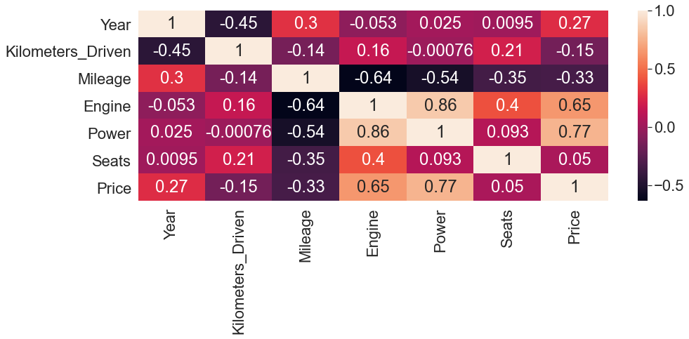

```python
plt.figure(figsize=(15,5))
sns.heatmap(UCD.corr(), annot=True)
plt.show()
```

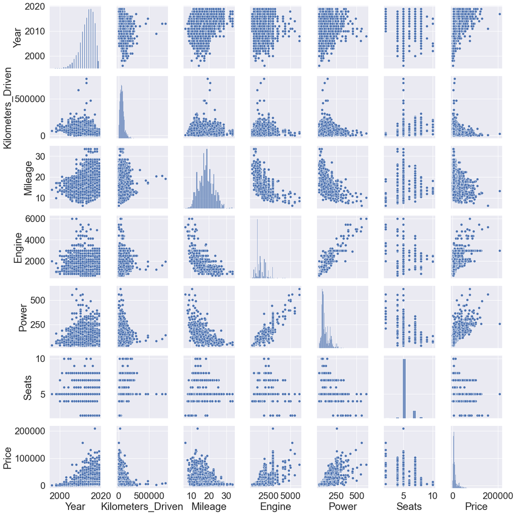

```python
sns.pairplot(UCD) #pairplot
plt.show()
```

- As the dependent variable, Price charts are the ones we should examine most closely
- We can see the correlations of price with year and power. The other variables are harder to interpret

```python
UCD.corr() # creates a table of how the numerical values are correlated
```

|  | Year | Kilometers_Driven | Mileage | Engine | Power | Seats | Price |
| --- | --- | --- | --- | --- | --- | --- | --- |
| Year | 1.000000 | -0.449732 | 0.295289 | -0.052895 | 0.024907 | 0.009498 | 0.271894 |
| Kilometers_Driven | -0.449732 | 1.000000 | -0.142629 | 0.157881 | -0.000761 | 0.213495 | -0.151319 |
| Mileage | 0.295289 | -0.142629 | 1.000000 | -0.636757 | -0.539451 | -0.348213 | -0.332975 |
| Engine | -0.052895 | 0.157881 | -0.636757 | 1.000000 | 0.857315 | 0.401766 | 0.651680 |
| Power | 0.024907 | -0.000761 | -0.539451 | 0.857315 | 1.000000 | 0.093265 | 0.766180 |
| Seats | 0.009498 | 0.213495 | -0.348213 | 0.401766 | 0.093265 | 1.000000 | 0.049887 |
| Price | 0.271894 | -0.151319 | -0.332975 | 0.651680 | 0.766180 | 0.049887 | 1.000000 |

#### Numerical vs Numerical

```python
from numpy.polynomial.polynomial import polyfit
```

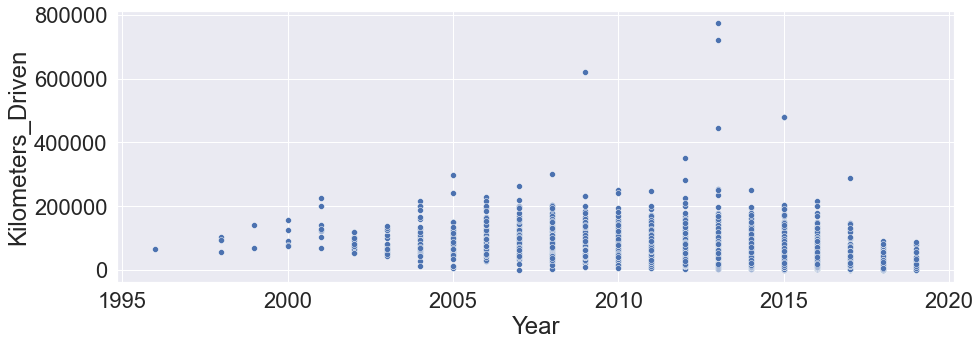

```python
#Year v Km Driven


figure = plt.figure(figsize=(15,5))

ax = sns.scatterplot(x='Year',y='Kilometers_Driven', data=UCD) # scatter plot is a good choice for this data because bmi is continuous
```

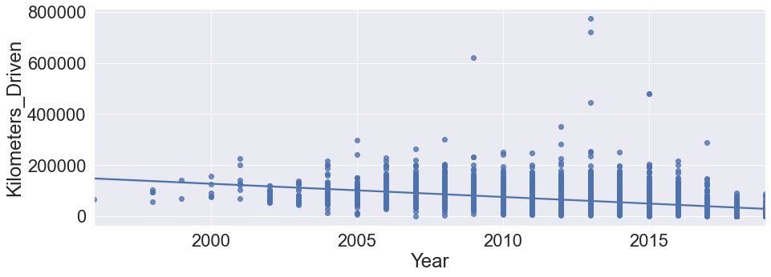

```python
figure = plt.figure(figsize=(15,5)) # adding a trend line will give us a better understanding of correlation

sns.regplot(x="Year", y="Kilometers_Driven", data=UCD);
```

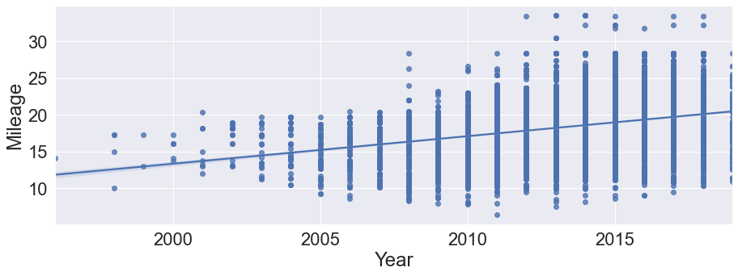

```python
# Year vs Mileage

figure = plt.figure(figsize=(15,5))

sns.regplot(x="Year", y="Mileage", data=UCD);
```

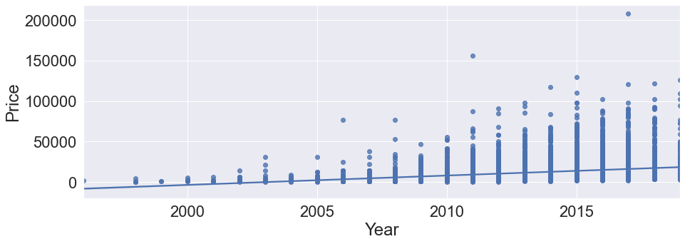

```python
# Year vs Price

figure = plt.figure(figsize=(15,5))

sns.regplot(x="Year", y="Price", data=UCD);
```

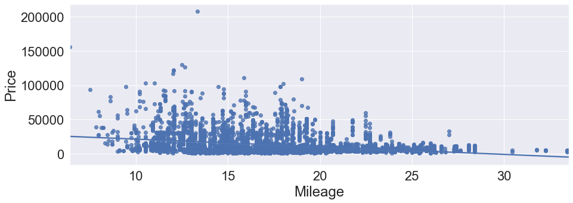

```python
# Mileage v Price

figure = plt.figure(figsize=(15,5))

sns.regplot(x="Mileage", y="Price", data=UCD);
```

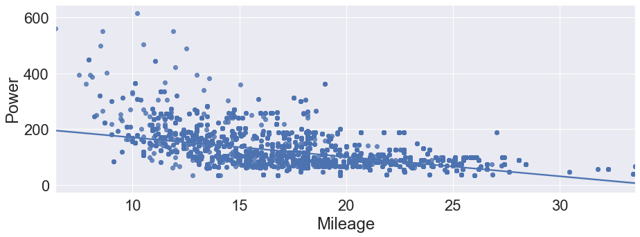

```python
# Mileage v Power

figure = plt.figure(figsize=(15,5))

sns.regplot(x="Mileage", y="Power", data=UCD);
```

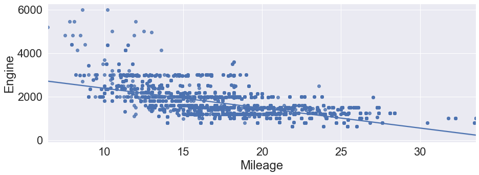

```python
# Mileage v Engine

figure = plt.figure(figsize=(15,5))

sns.regplot(x="Mileage", y="Engine", data=UCD);
```

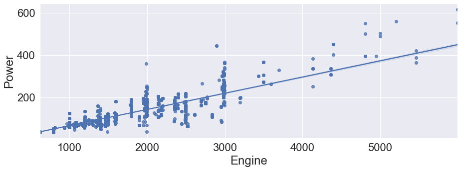

```python
# Engine v Power

figure = plt.figure(figsize=(15,5))

sns.regplot(x="Engine", y="Power", data=UCD);
```

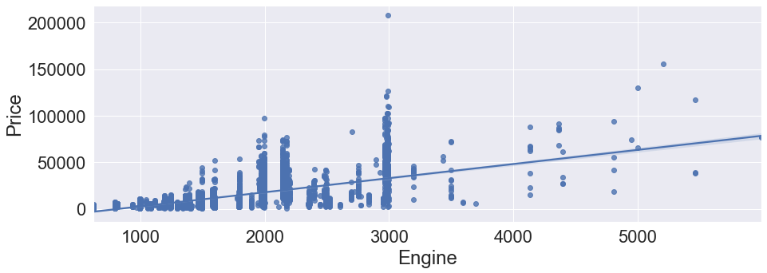

```python
# Engine v Price

figure = plt.figure(figsize=(15,5))

sns.regplot(x="Engine", y="Price", data=UCD);
```

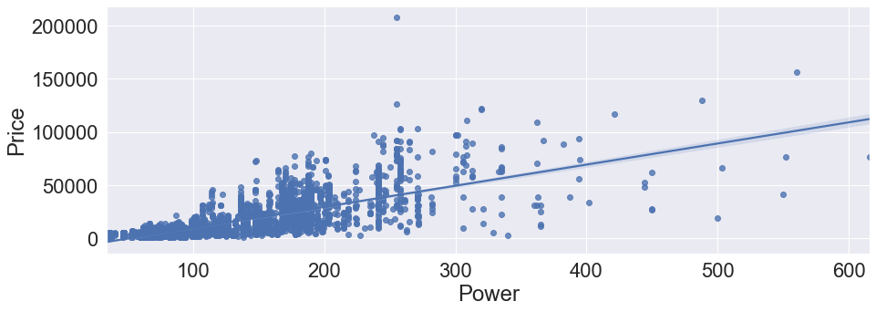

```python
# Power v Price

figure = plt.figure(figsize=(15,5))

sns.regplot(x="Power", y="Price", data=UCD);
```

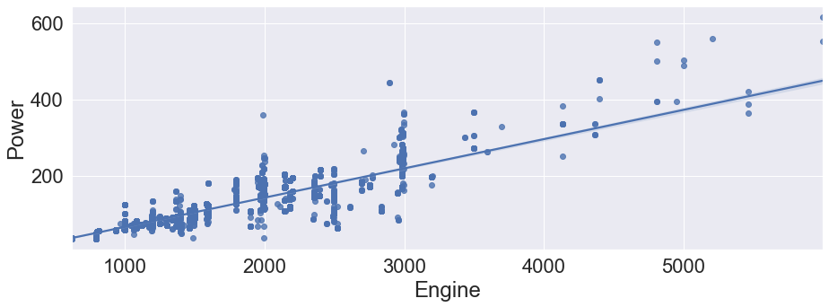

```python
# Engine v Power

figure = plt.figure(figsize=(15,5))

sns.regplot(x="Engine", y="Power", data=UCD);
```

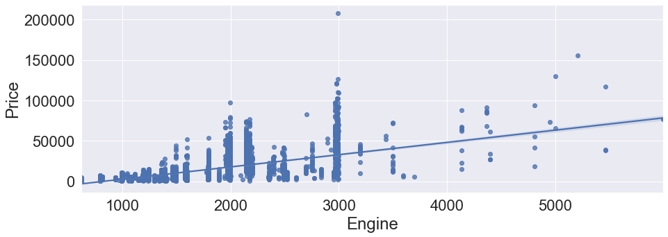

```python
# Engine v Price

figure = plt.figure(figsize=(15,5))

sns.regplot(x="Engine", y="Price", data=UCD);
```